# Hjemmeopgave 1 - Matematik 1a

#### s183710

#### 29-09-2024

## Opgave a)

#### **Afgør om følgende to logiske udsagn er logisk ækvivalente:**

**$(P ∧ Q) ⇒ R$ og $¬P ∨ (Q ⇒ R)$**

Vi opstiller vores sandhedstabel.

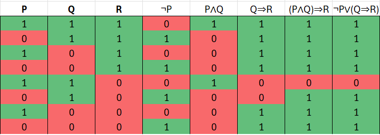

Som vi kan se, er de sidste to søjler identiske, og derfor logisk ækvivalente.

## Opgave b)

#### **Find alle reelle tal x som opfylder ligningen $|x-1|^2 = x^2 + |x|$.**

For at løse ligningen $ |x-1|^2 = x^2 + |x| $, deler vi problemet op i to tilfælde baseret på værdien af $x$.

#### Tilfælde 1: $x \geq 0$

Når $x \geq 0$, er $ |x| = x $ og $ |x-1| = x-1 $ (da $x \geq 1$ eller $0 \leq x < 1$).

Ligningen bliver: $$ (x-1)^2 = x^2 + x $$ Udvider venstresiden: $$ x^2 - 2x + 1 = x^2 + x $$ Trækker $x^2$ fra begge sider: $$ -2x + 1 = x $$ Løser for $x$: $$ 1 = 3x \implies x = \frac{1}{3} $$ Da $x = \frac{1}{3}$ opfylder $x \geq 0$, er det en gyldig løsning i dette tilfælde.

#### Tilfælde 2: $x < 0$

Når $x < 0$, er $ |x| = -x $ og $ |x-1| = -(x-1) = -x+1 $.

Ligningen bliver: $$ (-x + 1)^2 = x^2 + (-x) $$ Udvider venstresiden: $$ x^2 - 2x + 1 = x^2 - x $$ Trækker $x^2$ fra begge sider: $$ -2x + 1 = -x $$ Løser for $x$: $$ 1 = x $$ Men $x = 1$ opfylder ikke $x < 0$, så der er ingen løsning i dette tilfælde.

#### Samlet resultat

Den eneste løsning, der opfylder alle betingelserne, er $x = \frac{1}{3}$.

Derfor er den entydige løsning: $$ \boxed{x = \frac{1}{3}} $$

## Opgave c)

#### **Givet funktionen f : $R→R$ med forskriften**

$$f(x) = 4x^2+ 4|x −1|.$$

#### **1. Beregn funktionens værdimængde.**

Vi skal beregne $Vm(f)$.

For at finde værdimængden af funktionen $ f(x) = 4x^2 + 4|x - 1| $, betragter vi først, hvordan funktionen opfører sig for forskellige værdier af $ x $.

- For $ x \geq 1 $: $$ f(x) = 4x^2 + 4(x - 1) = 4x^2 + 4x - 4 $$ Dette er en parabel, der åbner opad med toppunkt i $ x = -\frac{b}{2a} = -\frac{4}{8} = -\frac{1}{2} $. Men da vi kun betragter $ x \geq 1 $, vil funktionen stige uden grænse.
- For $ x < 1 $: $$ f(x) = 4x^2 + 4(1 - x) = 4x^2 - 4x + 4 $$ Dette er også en parabel, der åbner opad med toppunkt i $ x = \frac{b}{2a} = \frac{4}{8} = \frac{1}{2} $. I dette interval vil funktionen stige uden grænse.

Således er værdimængden for funktionen $ f(x) = 4x^2 + 4|x - 1| $ givet ved: $$ \boxed{Vm(f) = [3, \infty[} $$

#### **2. Afgør om funktionen er injektiv**

En funktion er injektiv, hvis der for to vilkårlige punkter $ x_1 $ og $ x_2 $ i definitionsmængden gælder: $$ f(x_1) = f(x_2) \implies x_1 = x_2 $$

Men da funktionen består af to dele, der begge er kontinuerte og voksende for henholdsvis $ x \geq 1 $ og $ x < 1 $, vil der altid findes to forskellige $ x $-værdier, der giver samme $ f(x) $.

Således er funktionen **ikke** injektiv.

## Opgave d)

#### **Der opgives for et komplekst tal $ z $ at $ \arg(z) = -\pi/3 $ og $ |z|= 2 $.**

#### **1. Beregn de polære koordinater for det komplekse tal $z^7$.**

#### **2. Skriv tallet $z^7$ på rektangulær form.**

For at løse opgaven, skal vi først konvertere det givne komplekse tal $ z $ til polære koordinater og derefter beregne $ z^7 $.

### Trin 1: Konvertering til polære koordinater

Det givne komplekse tal $ z $ har en vinkel på $ -\frac{\pi}{3} $ og en størrelse (modulus) på 2. Polære koordinater for et komplekst tal er givet ved: $$ z = |z| \cdot (\cos(\theta) + i\sin(\theta)) $$ hvor $ |z| = 2 $ og $ \theta = -\frac{\pi}{3} $.

Dette giver os: $$ z = 2 \left( \cos\left(-\frac{\pi}{3}\right) + i\sin\left(-\frac{\pi}{3}\right) \right) $$

Beregning af cos og sin: $$ \cos\left(-\frac{\pi}{3}\right) = \cos\left(\frac{\pi}{3}\right) = \frac{1}{2} $$ $$ \sin\left(-\frac{\pi}{3}\right) = -\sin\left(\frac{\pi}{3}\right) = -\frac{\sqrt{3}}{2} $$

Så: $$ z = 2 \left( \frac{1}{2} - i\frac{\sqrt{3}}{2} \right) = 1 - i\sqrt{3} $$

### Trin 2: Beregning af $ z^7 $

For at beregne $ z^7 $ bruger vi DeMoivres formel, som siger: $$(r \cdot (cos θ + i \cdot sin θ))^n = r^n \cdot (cos (nθ) + i \cdot sin (nθ))$$ Dvs. $$ z^n = |z|^n \left( \cos(n\theta) + i\sin(n\theta) \right) $$ hvor $ n = 7 $, $ |z| = 2 $, og $ \theta = -\frac{\pi}{3} $.

Beregning af $ z^7 $: $$ z^7 = 2^7 \left( \cos\left(7 \cdot (-\frac{\pi}{3})\right) + i\sin\left(7 \cdot (-\frac{\pi}{3})\right) \right) $$

Vi kan reducere vinklen: $$ Arg(z)=-\frac{7\pi}{3} + 2\pi = -\frac{7\pi}{3} + \frac{6\pi}{3} = -\frac{\pi}{3} $$ Så det er den samme vinkel, som vi startede med.

Beregning af cos og sin: $$ \cos\left(-\frac{7\pi}{3}\right) = \cos\left(\frac{\pi}{3}\right) = \frac{1}{2} $$ $$ \sin\left(-\frac{7\pi}{3}\right) = -\sin\left(\frac{\pi}{3}\right) = -\frac{\sqrt{3}}{2} $$

Så: $$ z^7 = 2^7 \left( \frac{1}{2} - i\frac{\sqrt{3}}{2} \right) = 128 \left( \frac{1}{2} - i\frac{\sqrt{3}}{2} \right) $$

### Trin 3: Skriv $ z^7 $ på rektangulær form

Vi multiplicerer koefficienterne med cos og sin: $$ z^7 = 128 \left( \frac{1}{2} - i\frac{\sqrt{3}}{2} \right) = 64 - 64i\sqrt{3} $$

### Svar:

1. De polære koordinater for $ z^7 $ er givet ved: $$ z^7 = \boxed{(128,\left(-\frac{\pi}{3}\right))} $$
2. Det komplekse tal $ z^7 $ på rektangulær form er: $$ z^7 = \boxed{64 - 64i\sqrt{3}} $$

## Opgave e)

#### **Løs den binome ligning $z^3= i$. Svarene ønskes givet på rektangulær form samt indtegnet i den komplekse talplan.**

Løsningen til ligningen kan findes ved at isolere $ z $. Vi starter med at skrive $ i $ på polær form, hvilket er $ i = e^{i\pi/2} $. Således har vi:

$$ z^3 = e^{i\pi/2} $$

Løsningen til denne ligning kan findes ved at tage 3. rod på begge sider:

$$ z = e^{i(\pi/2 + 2p\pi)/3}, \quad \text{for} \quad p = 0, 1, 2 $$

Dette giver tre forskellige løsninger:

1. For $ p = 0 $:

$$ z_1 = e^{i((\pi/2) + (2 \cdot 0 \cdot \pi))/3} = e^{i(\pi/6)} = \cos(\pi/6) + i\sin(\pi/6) = \boxed{\frac{\sqrt{3}}{2} + i\frac{1}{2}} $$

2. For $ p = 1 $:

$$ z_2 = e^{i((\pi/2) + (2 \cdot 1 \cdot \pi))/3} = \cos(5\pi/6) + i\sin(5\pi/6) = \boxed{-\frac{\sqrt{3}}{2} + i\frac{1}{2}} $$

3. For $ p = 2 $:

$$ z_3 = e^{i((\pi/2) + (2 \cdot 2 \cdot \pi))/3} = e^{i((\pi/2) + (4 \cdot \pi))/3} = \cos(5\pi/3) + i\sin(5\pi/3) = \boxed{ -i} $$

Disse løsninger kan nu indtegnes i den komplekse talplan.

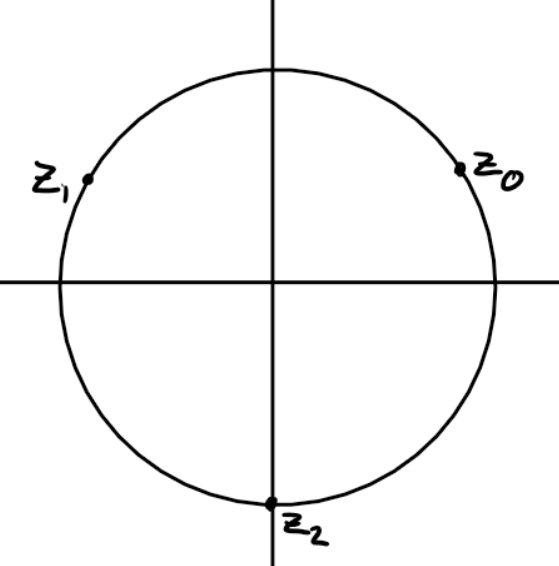

## Opgave f)

#### **Som sædvanligt betegnes hovedargument af et komplekst tal $z$ med $Arg(z)$. Afgør om følgende udsagn er sande:**

#### 1. $ \text{Im}(z) > 0 \Rightarrow \text{Arg}(z) > 0 $

For at $ \text{Arg}(z) > 0 $, skal punktet $ (a, b) $ befinde sig i første eller anden kvadrant. Det vil det altid gøre, hvis $Im(z)>0$.

Udsagnet er altså sandt.

#### 2. $ \text{Arg}(z) \leq 0 \Rightarrow \text{Im}(z) \leq 0 $

- Hvis $ \text{Arg}(z) = 0 $, så ligger $ z $ på den reelle akse, og $ \text{Im}(z) = 0 $.
- Hvis $ \text{Arg}(z) < 0 $, så ligger $ z $ i tredje eller fjerde kvadrant.

For at $ \text{Arg}(z) \leq 0 $, skal punktet $ (a, b) $ befinde sig i tredje eller fjerde kvadrant.

Udsagnet passer altså.

#### 3. $ \text{Im}(z) = 0 \Rightarrow \text{Arg}(z) = 0 $

Dette udsagn siger, at hvis den imaginære del af $ z $ er nul, så er argumentet for $ z $ nul. Dette passer ikke, da $Arg(z)=\pi$ også kan gælde for et komplekst tal med $Im(z)=0$.

#### Konklusion

Kun de første to udsagn er sande. Det sidste passer ikke.